# September 2026 Assessment developments

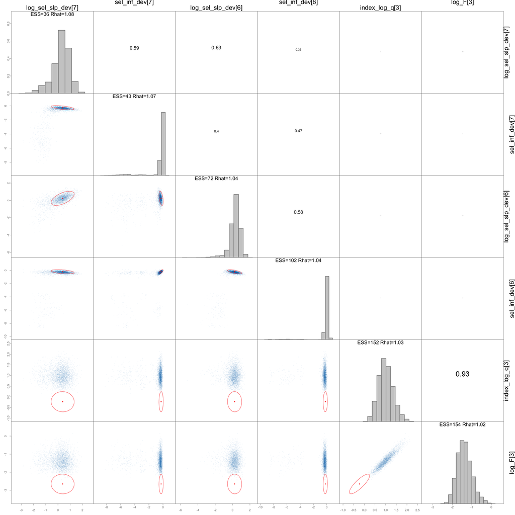

Figure 35: Joint posterior relationships for the six Model 26.0 parameters with the lowest bulk effective sample sizes. Diagonal panels report bulk ESS and R-hat; upper panels report posterior correlations; and lower panels show retained draws in blue, the maximum-likelihood estimate as a red point, and the local 95% Hessian ellipse in red.

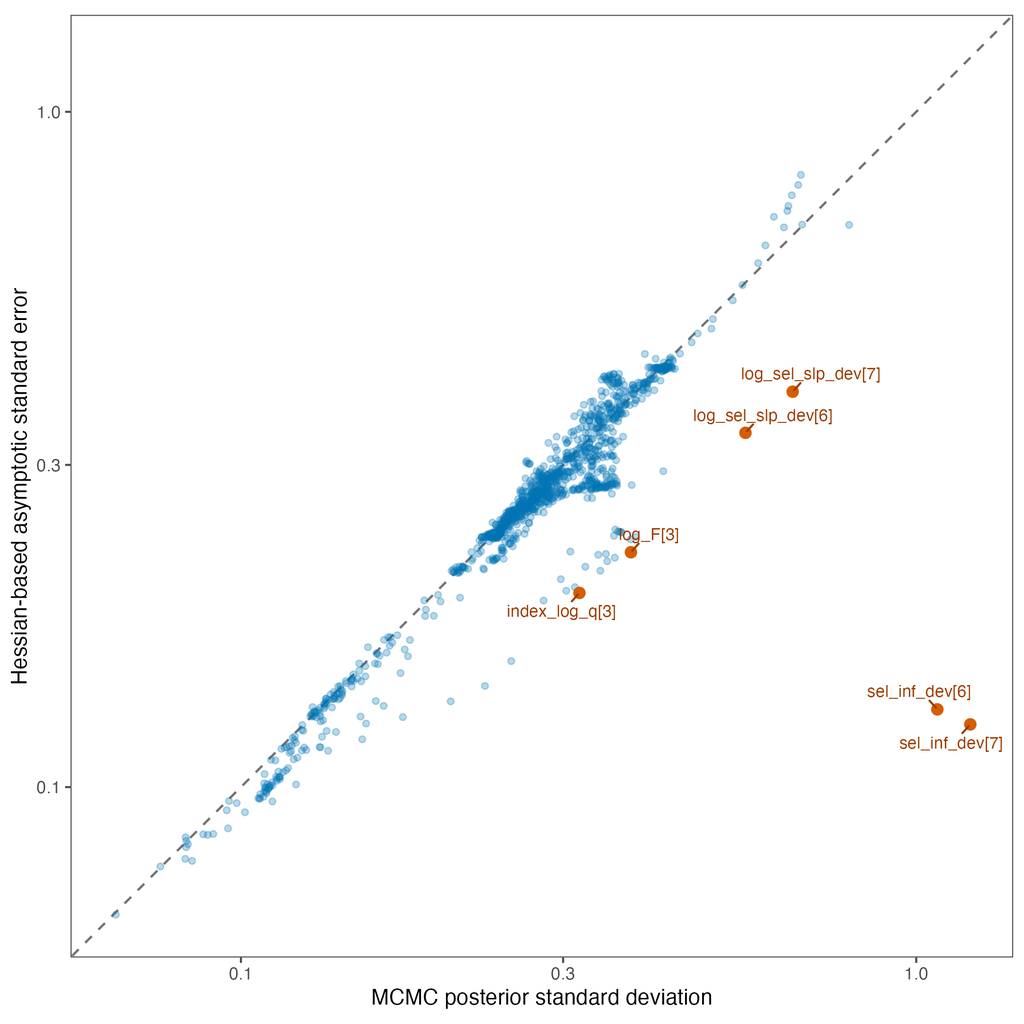

Figure 36: MCMC posterior standard deviations compared with Hessian-based asymptotic standard errors for all 1,218 Model 26.0 parameters.

| Diagnostic | Result | Review target | Outcome |
| --- | --- | --- | --- |
| Chains | 4 | 4 | Pass |
| Warmup iterations per chain | 1,000 | 1,000 | Pass |
| Retained draws per chain | 1,000 | 1,000 | Pass |
| Maximum R-hat | 1.075 | 1.01 or lower | Review |
| Minimum bulk ESS | 36 | 400 or higher | Review |
| Minimum tail ESS | 22 | 400 or higher | Review |
| Divergences | 0 | 0 | Pass |
| Maximum-tree-depth events | 0 | 0 | Pass |
| Minimum E-BFMI | 1.001 | above 0.30 | Pass |

Table 19: SparseNUTS configuration and sampling diagnostics for the complete Model 26.0 joint objective.

## Appendix 5: Reproducible model run methods

The model workflow keeps the editable report and analysis code under version control while storing large fit objects in the local analysis repository. The Rceattle library is pinned to version 5.23.0 from commit `adf22f84b399e84e3b9a707e0b3bbb1624179a27` on the `dsem-v5-integration` branch. This preserves the exact model code used for the results. Each script checks the expected package version before fitting. The base assessment specification uses the established nonparametric selectivity, omits the two-dimensional age-by-year AR1 option, sets DSEM to `NULL`, and retains recruitment deviations as fixed parameters.

The following sequence reproduces the analysis. First, install the pinned Rceattle revision and afscOSA 0.0.1 in an isolated R library. Second, run M23-01 when the ADMB-to-Rceattle translation check needs rebuilding. Third, from the analysis repository, run M26-01; it reads the 1964–2024 assessment workbook, fits the model in two stages, saves the complete fit locally, and creates the bridge, OSA, and jitter products. Fourth, run M26-02 through M26-04 for the self-test and lag-preserving retrospective evaluations. Fifth, run M26-09 and M26-11 for whole-index and sampling-event influence. Sixth, run M26-05 followed by M26-06 for the `spmR` projection handoff. Finally, run the research evaluations M26-07 and M26-10 separately from the operational fit, then run M26-12 to summarize the retained SparseNUTS draws. Run M26-13 after M26-01 to rebuild the fitted index and age-composition displays from the saved Model 26.0 object.

| Step | Script ID | Script | Purpose |
| --- | --- | --- | --- |
| 1 | M23-01 | run_model_23_0_vs_23_2_admb_comparison.R | Rebuild and compare the original and Rceattle-aligned ADMB bridge runs |
| 2 | M26-01 | run_model_26_rceattle_5_23.R | Fit the two-stage Model 26.0 base and create bridge OSA and jitter diagnostics |
| 3 | M26-02 | run_model_26_self_test_5_23.R | Simulate and refit the configured model for parameter and state recovery |
| 4 | M26-03 | run_model_26_retrospective_sensitivity_5_23.R | Run nine peels with stream-specific data lags and terminal selectivity treatment |
| 5 | M26-04 | run_model_26_retrospective_data_sensitivity_5_23.R | Test observation blocks responsible for the 2020–2021 retrospective transition |
| 6 | M26-09 | run_model_26_index_series_sensitivity_5_23.R | Refit after removing the complete BTS ATS or AVO fleet contribution while retaining CPUE |
| 7 | M26-05 | write_spmr_projection_inputs.R | Translate the fitted population state and biological schedules into SPM files |
| 8 | M26-06 | run_model_26_spmr_projection_5_23.R | Run and summarize the seven Tier 3 projection alternatives |
| 9 | M26-07 | run_model_26_dsem_5_23_pathways.R | Fit the separate exploratory recruitment-pathway models |
| 10 | M26-10 | run_model_26_sparsenuts_5_23.R | Sample the complete joint Model 26.0 objective with four dense-metric chains |
| 11 | M26-11 | run_model_26_case_deletion_5_23.R | Build the observation schedule and refit after deleting selected complete sampling events |
| 12 | M26-12 | plot_model_26_sparsenuts_diagnostics.R | Create pairs and uncertainty-comparison diagnostics from the retained SparseNUTS draws |
| 13 | M26-13 | plot_model_26_fits.R | Create fitted index and annual age-composition displays from the active Model 26.0 rows |

Table 20: Model 23.2 bridge and Model 26.0 script register.

## Appendix 6: Observation continuity and case-deletion influence

This diagnostic separates whether an observation was available and used from how much the accepted fit changes when a fitted sampling event is removed. The observation-continuity panel uses an explicit assessment-input schedule: annual for the fishery, BTS, and AVO rows and even years for ATS rows. Years after 2024 are shown only to distinguish the current fitted span; the schedule does not imply a commitment about future field operations.

The continuity panel distinguishes events present in the Model 26.0 input, scheduled events that are absent, years outside a row’s fitted span, and years after the terminal fitted year (Figure 37). It also shows where age-1 proportions are fitted separately from the main age composition. This makes survey timing, composition coverage, and recent gaps visible without treating the schedule as a prediction.

The case-deletion analysis removes an entire fitted index observation or composition row for one selected fleet-year event and then refits the complete model. All 11 refits reached convergence status OK with positive-definite Hessians. The 2024 BTS biomass index had the largest terminal spawning biomass effect (-5.28%) and lowered terminal age-1 recruitment by 25.31%. Removing the 2024 ATS age composition lowered terminal spawning biomass by 2.66% and raised terminal recruitment by 25.48%; its largest recruitment change across all years was 54.24%. Removing the 2024 AVO index raised terminal spawning biomass by 5.10% and terminal recruitment by 5.93%. Other selected events produced smaller terminal changes (Figure 38; Table 21).

These values describe influence within the current fitted model. Decisions about observation weighting draw on the full data-quality record, sampling design, fit diagnostics, and biological interpretation. Script M26-11 creates the explicit schedule, refits the selected cases, and saves each compact checkpoint locally.

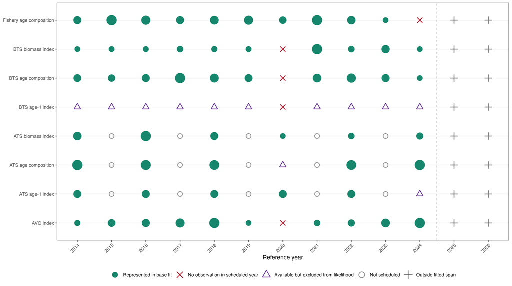

Figure 37: Observation continuity for fishery, BTS, ATS, and AVO inputs from 2014 through 2026.

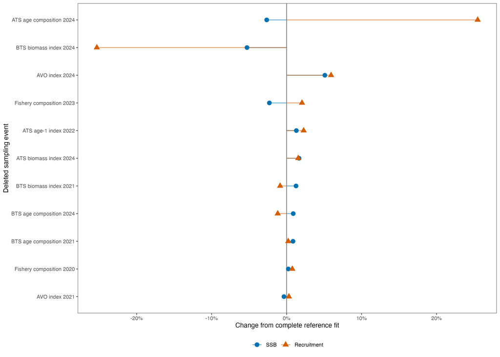

Figure 38: Influence of selected sampling-event deletions on terminal spawning biomass and age-1 recruitment.

| Sampling event removed | Terminal SSB change (%) | Terminal recruitment change (%) | Largest recruitment change (%) |
| --- | --- | --- | --- |
| Fishery composition 2020 | +0.23 | +0.76 | 14.50 |
| Fishery composition 2023 | -2.30 | +2.05 | 11.71 |
| BTS biomass index 2021 | +1.26 | -0.87 | 1.39 |
| BTS biomass index 2024 | -5.28 | -25.31 | 25.31 |
| BTS age composition 2021 | +0.85 | +0.21 | 7.48 |
| BTS age composition 2024 | +0.88 | -1.18 | 15.77 |
| ATS biomass index 2024 | +1.66 | +1.55 | 2.47 |
| ATS age composition 2024 | -2.66 | +25.48 | 54.24 |
| ATS age-1 index 2022 | +1.30 | +2.27 | 8.65 |
| AVO index 2021 | -0.35 | +0.31 | 0.56 |
| AVO index 2024 | +5.10 | +5.93 | 9.90 |

Table 21: Influence of selected sampling-event deletions on terminal Model 26.0 spawning biomass and recruitment.

## Appendix 7: Glossary of acronyms

This glossary follows the ASAR package convention of maintaining one alphabetical source table with `Label`, `Acronym`, and `Meaning` fields. The label provides a stable key for document automation, while the acronym and meaning provide the reader-facing text. The report-specific source file can be updated once and reused in future output formats (Table 22).

|  | Acronym | Meaning |
| --- | --- | --- |
| 1 | ABC | acceptable biological catch |
| 2 | ADMB | Automatic Differentiation Model Builder |
| 3 | AFSC | Alaska Fisheries Science Center |
| 4 | AI | artificial intelligence |
| 5 | AIC | Akaike information criterion |
| 6 | AR1 | first-order autoregressive structure |
| 7 | ATS | acoustic-trawl survey |
| 8 | AVO | acoustic vessel-of-opportunity |
| 9 | B35% | spawning biomass reference point associated with 35 percent of unfished spawning potential |
| 10 | B40% | spawning biomass reference point associated with 40 percent of unfished spawning potential |
| 11 | BSAI | Bering Sea and Aleutian Islands |
| 12 | BTS | bottom-trawl survey |
| 13 | CEATTLE | Climate-enhanced Age-based model with Temperature-specific Trophic Linkages and Energetics |
| 14 | CPUE | catch per unit effort |
| 15 | DSEM | dynamic species environment model |
| 16 | E-BFMI | energy Bayesian fraction of missing information |
| 17 | EBS | eastern Bering Sea |
| 18 | ESP | Ecosystem and Socioeconomic Profile |
| 19 | ESR | Ecosystem Status Report |
| 20 | ESS | effective sample size |
| 21 | FT-NIR | Fourier-transform near-infrared method |
| 22 | FT-NIRS | Fourier-transform near-infrared spectroscopy |
| 23 | GOA | Gulf of Alaska |
| 24 | HMC | Hamiltonian Monte Carlo |
| 25 | ISS | input sample size |
| 26 | LR | likelihood ratio |
| 27 | MCMC | Markov chain Monte Carlo |
| 28 | MLE | maximum-likelihood estimate |
| 29 | NLL | negative log likelihood |
| 30 | NOAA | National Oceanic and Atmospheric Administration |
| 31 | NPFMC | North Pacific Fishery Management Council |
| 32 | NUTS | no-U-turn sampler |
| 33 | OFL | overfishing limit |
| 34 | OSA | one-step-ahead |
| 35 | Q-Q | quantile-quantile |
| 37 | R-hat | rank-normalized potential scale-reduction statistic |
| 36 | Rceattle | R implementation of CEATTLE |
| 38 | RTMB | R Template Model Builder |
| 39 | SAFE | Stock Assessment and Fishery Evaluation |
| 40 | SDNR | standard deviation of normalized residuals |
| 41 | SparseNUTS | sparse-matrix implementation of the no-U-turn sampler |
| 42 | SPM | Standard Projection Model |
| 43 | SPR | spawning potential ratio |
| 44 | SRR | stock-recruit relationship |
| 45 | SSB | spawning stock biomass |
| 46 | SSC | Scientific and Statistical Committee |
| 47 | SST | sea-surface temperature |
| 48 | TMB | Template Model Builder |

Table 22: Acronyms used in the September 2026 assessment developments report.

## Appendix 8: Fishery length frequency patterns

This appendix summarizes exploratory seasonal and spatial patterns in observed pollock length-frequency samples. Its scope is exploratory description; assessment-model tests belong in separate analyses. The source analysis includes pollock observations from 1991 onward, excludes observations below 20 cm, and accumulates fish 65 cm and longer in a 65-cm-plus group. Length frequencies are normalized within each displayed year and grouping. A season includes samples collected before June 20; B season data are from June 20 onward. Earlier years appear at the top of each figure.

### 6.0.1 Change from 2025 to 2026

The observed length distribution shifted toward smaller fish from 2025 to 2026. Across seasons, mean sampled length declined from 46.17 to 44.81 cm, while the median remained 46 cm. The percentage longer than 46 cm decreased from 46.40% to 43.96%, and the percentage at or below 35 cm increased from 4.03% to 9.86%.

The shift occurred primarily in the B-season samples. B-season mean length declined from 45.93 cm in 2025 to 42.55 cm in 2026, and the median declined from 46 to 43 cm. The proportion longer than 46 cm decreased from 48.90% to 34.76%, while the proportion at or below 35 cm increased from 6.79% to 17.54%. Both B-season area groups shifted toward smaller fish. In the western group (`NMFS_AREA > 519`), mean length declined from 44.26 to 39.39 cm and the percentage at or below 35 cm increased from 9.86% to 29.24%. In the eastern group (`NMFS_AREA < 520`), mean length declined from 48.55 to 45.62 cm and the percentage longer than 46 cm decreased from 70.13% to 49.88%.

The A-season change was smaller and differed in shape. Mean length declined from 46.39 to 45.82 cm and the median remained 46 cm, while the percentages longer than 46 cm and at or below 35 cm both increased. This indicates greater representation in the tails of the sampled A-season distribution in 2026. Sample coverage also changed: the A-season count increased from 91,912 to 101,038 observations, whereas the B-season count decreased from 80,749 to 45,057. These are unstandardized sample distributions, so the differences describe the available observations and may reflect changes in sampling as well as changes in the fish encountered by the fishery.

### 6.0.2 A- and B-season distributions

The seasonal distributions show the larger 2026 shift toward smaller fish in the B season and the broader-tailed A-season pattern (Figure 39).

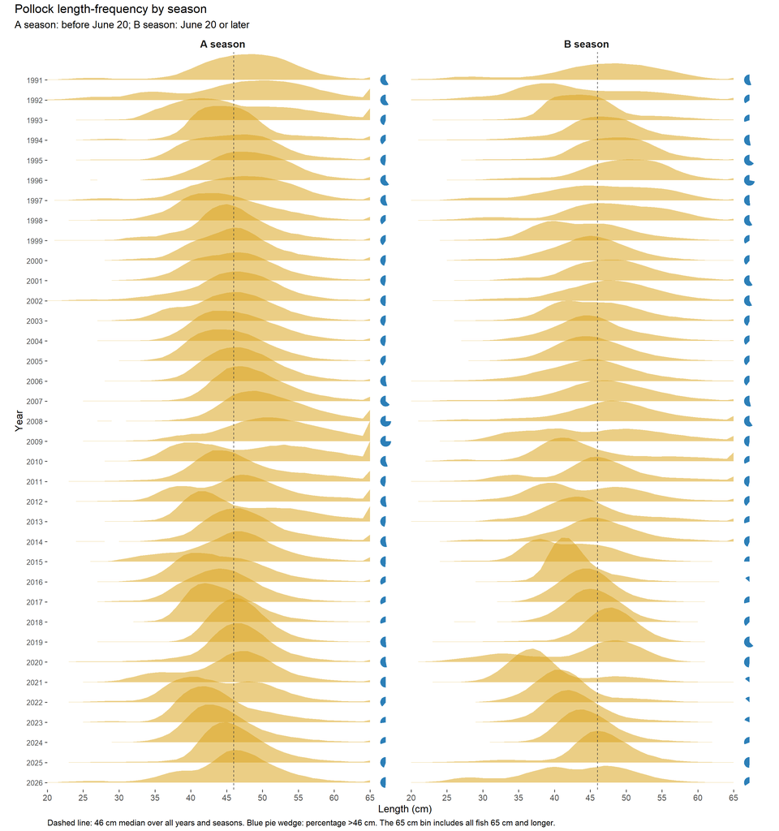

Figure 39: Pollock length-frequency proportions by season. The left panel shows samples collected before June 20; the right panel shows samples collected from June 20 onward.

### 6.0.3 Combined-season distributions

The combined-season series places the 2026 increase in fish at or below 35 cm within the longer record of annual sample distributions (Figure 40).

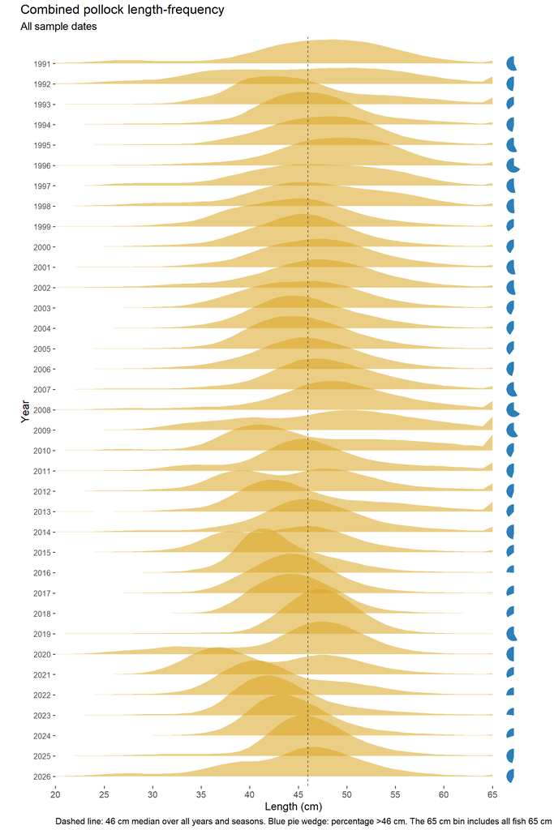

Figure 40: Pollock length-frequency proportions across both seasons.

### 6.0.4 B-season distributions by NMFS area

The B-season area comparison shows a stronger shift toward smaller fish in the western group, while the eastern group retains a larger share above 46 cm (Figure 41).

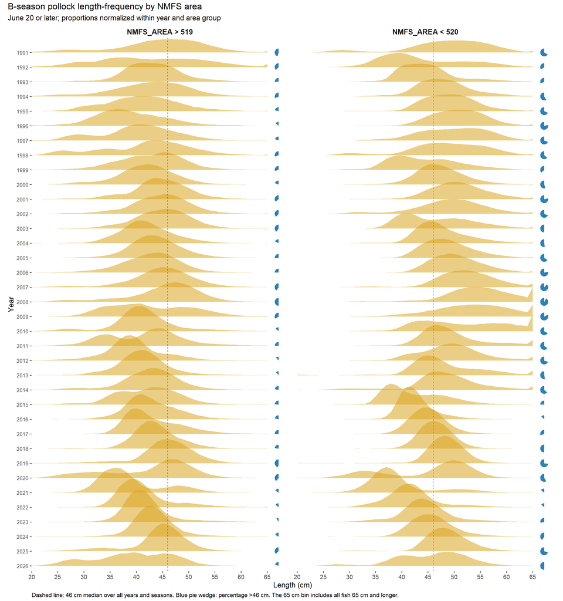

Figure 41: B-season pollock length-frequency proportions by NMFS area group. Samples were collected from June 20 onward. The left panel represents samples west of 170 degrees W; the right panel represents samples east of 170 degrees W, approximately west and east of the Pribilof Islands.